# si544-day6-more-basic-regression

Matthew Garvin

10/9/2019

# Overview:

1. Guess the Correlation (10 minutes)
2. A few words about “traditional” vs. “moderndive” representations (10 minutes)
3. Learning Checks 5.1, 5.2, and 5.3 (25 minutes)
4. Debrief (15 minutes)
5. Break (10 minutes)
6. Learning Checks 5.4, 5.5, and 5.6 (25 minutes)
7. Debrief (15 minutes)

## Guess the Correlation

Let’s start by playing a game: http://guessthecorrelation.com/

# Review of basic regression with two numerical variables

```r
library(tidyverse)
library(moderndive)
library(skimr)
library(gapminder)
```

```r
evals_ch5 <- evals %>%
  select(ID, score, bty_avg, age)
```

## (LC5.1) Conduct an exploratory data analysis on evals_ch5 with the outcome variable y being score and age as the explanatory variable x.

Remember, this involves three things:

Looking at the raw data values. Computing summary statistics. Creating data visualizations. What can you say about the relationship between age and teaching scores based on this exploration?

```r
# Insert your code here
glimpse(evals_ch5)
```

```
## Rows: 463
## Columns: 4
## $ ID      <int> 1, 2, 3, 4, 5, 6, 7, 8, 9, 10, 11, 12, 13, 14, 15, 16, 17, ...
## $ score   <dbl> 4.7, 4.1, 3.9, 4.8, 4.6, 4.3, 2.8, 4.1, 3.4, 4.5, 3.8, 4.5,...
## $ bty_avg <dbl> 5.000, 5.000, 5.000, 5.000, 3.000, 3.000, 3.000, 3.333, 3.3...
## $ age     <int> 36, 36, 36, 36, 59, 59, 59, 51, 51, 40, 40, 40, 40, 40, 40,...
```

```r
skim(evals_ch5)
```

Data summary

| Name | evals_ch5 |
| --- | --- |
| Number of rows | 463 |
| Number of columns | 4 |
| _______________________ |  |
| Column type frequency: |  |
| numeric | 4 |
| ________________________ |  |
| Group variables | None |

**Variable type: numeric**

| skim_variable | n_missing | complete_rate | mean | sd | p0 | p25 | p50 | p75 | p100 | hist |
| --- | --- | --- | --- | --- | --- | --- | --- | --- | --- | --- |
| ID | 0 | 1 | 232.00 | 133.80 | 1.00 | 116.50 | 232.00 | 347.5 | 463.00 | ▇▇▇▇▇ |
| score | 0 | 1 | 4.17 | 0.54 | 2.30 | 3.80 | 4.30 | 4.6 | 5.00 | ▁▁▅▇▇ |
| bty_avg | 0 | 1 | 4.42 | 1.53 | 1.67 | 3.17 | 4.33 | 5.5 | 8.17 | ▃▇▇▃▂ |
| age | 0 | 1 | 48.37 | 9.80 | 29.00 | 42.00 | 48.00 | 57.0 | 73.00 | ▅▆▇▆▁ |

```r
evals_ch5 %>%
  get_correlation(formula = score ~ age)
```

```
## # A tibble: 1 x 1
##      cor
##    <dbl>
## 1 -0.107
```

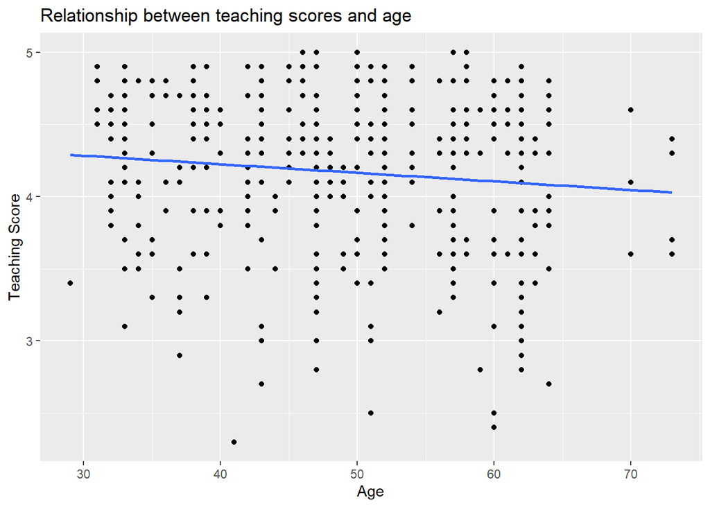

```r
ggplot(data = evals_ch5, mapping = aes(x = age, y = score)) +
  geom_point()+
  labs(x = "Age", y = "Teaching Score", title = "Relationship between teaching scores and age") +
  geom_smooth(method = "lm", se = FALSE)
```

## (LC5.2) Fit a new simple linear regression using lm(score ~ age, data = evals_ch5) where age is the explanatory variable x.

Get information about the “best-fitting” line from the regression table by applying the get_regression_table() function. How do the regression results match up with the results from your earlier exploratory data analysis?

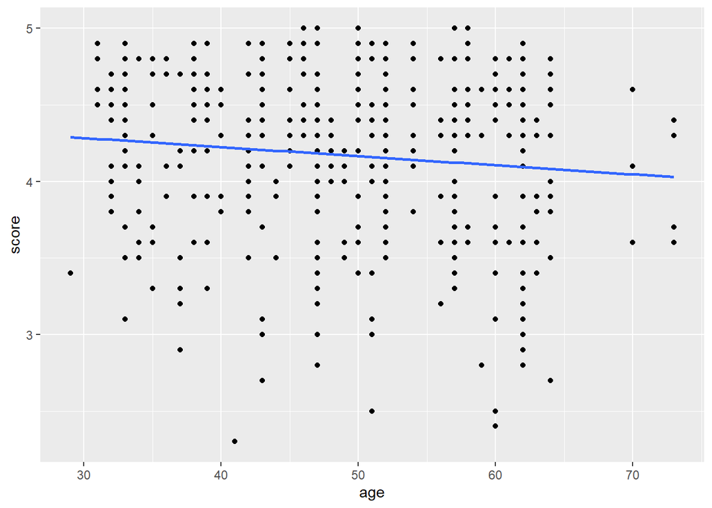

```r
# Insert your code here
ggplot(evals_ch5, aes(x = age, y = score)) +
  geom_point() +
  geom_smooth(method = "lm", se = FALSE)
```

```r
model <- lm(score ~ age, data = evals_ch5)
get_regression_table(model)
```

```
## # A tibble: 2 x 7
##   term      estimate std_error statistic p_value lower_ci upper_ci
##   <chr>        <dbl>     <dbl>     <dbl>   <dbl>    <dbl>    <dbl>
## 1 intercept    4.46      0.127     35.2    0        4.21     4.71
## 2 age         -0.006     0.003     -2.31   0.021   -0.011   -0.001
```

```r
get_regression_summaries(model)
```

```
## # A tibble: 1 x 8
##   r_squared adj_r_squared   mse  rmse sigma statistic p_value    df
##       <dbl>         <dbl> <dbl> <dbl> <dbl>     <dbl>   <dbl> <dbl>
## 1     0.011         0.009 0.292 0.540 0.541      5.34   0.021     2
```

```r
skim(evals_ch5)
```

Data summary

| Name | evals_ch5 |
| --- | --- |
| Number of rows | 463 |
| Number of columns | 4 |
| _______________________ |  |
| Column type frequency: |  |
| numeric | 4 |
| ________________________ |  |
| Group variables | None |

**Variable type: numeric**

| skim_variable | n_missing | complete_rate | mean | sd | p0 | p25 | p50 | p75 | p100 | hist |
| --- | --- | --- | --- | --- | --- | --- | --- | --- | --- | --- |
| ID | 0 | 1 | 232.00 | 133.80 | 1.00 | 116.50 | 232.00 | 347.5 | 463.00 | ▇▇▇▇▇ |
| score | 0 | 1 | 4.17 | 0.54 | 2.30 | 3.80 | 4.30 | 4.6 | 5.00 | ▁▁▅▇▇ |
| bty_avg | 0 | 1 | 4.42 | 1.53 | 1.67 | 3.17 | 4.33 | 5.5 | 8.17 | ▃▇▇▃▂ |
| age | 0 | 1 | 48.37 | 9.80 | 29.00 | 42.00 | 48.00 | 57.0 | 73.00 | ▅▆▇▆▁ |

## (LC5.3) Generate a data frame of the residuals of the model where you used age as the explanatory x variable.

```r
# Insert your code here
res <- get_regression_points(model)
res
```

```
## # A tibble: 463 x 5
##       ID score   age score_hat residual
##    <int> <dbl> <int>     <dbl>    <dbl>
##  1     1   4.7    36      4.25    0.452
##  2     2   4.1    36      4.25   -0.148
##  3     3   3.9    36      4.25   -0.348
##  4     4   4.8    36      4.25    0.552
##  5     5   4.6    59      4.11    0.488
##  6     6   4.3    59      4.11    0.188
##  7     7   2.8    59      4.11   -1.31
##  8     8   4.1    51      4.16   -0.059
##  9     9   3.4    51      4.16   -0.759
## 10    10   4.5    40      4.22    0.276
## # ... with 453 more rows
```